# Bio4158/Bio5158 - Report 4

- Show All Code
- Hide All Code
- View Source

Exercise

Author

Group 22 - Nalan Kurnaz

Published

October 20, 2025

# The problem

The peppered moth (*Biston betularia* Lepidoptera : Geometridae) is a nocturnal insect common in Europe and North America. Adults fly at night and stay put during the day on birch trees. Adult coloration is variable, ranging from a clear form (typica) to a melanic form that is very dark (carbonaria), with many intermediate forms.

The proportion of individuals of each form has varied considerably in natural populations over the last 150 years. The melanic form was rare before 1850 but represented over 90% of the population in industrial sectors of England by 1900. According to Majerus (1998), J.W. Tutt was the first to suggest in 1896 an hypothesis to explain the temporal change in the proportion of the dark form.

**Biological hypothesis**: Differences in the relative frequency of the two forms arise because survival from bird predation of each depends on habitat color. In particular, the pale form is less visible in non-polluted environments when birch trees are covered by pale greyish lichens. Inversely, the dark form is favored in industrial areas where soot darkens their resting places. Therefore, the increase of the dark form (carbonaria) in England resulted from bird predation and a change in habitat (soot pollution).

# The study

In a study designed to test this hypothesis, a random sample of 30 insectivorous birds was used to estimate predation susceptibility of the pale and dark forms on both pale and dark substrates. **Two growth chamber** were set up containing branches and leaves:

1. **in the first, the branches and leaves were taken from a polluted area and were covered with soot (and were thus dark)**;
2. **in the second, the branches and leaves were taken from a non-polluted area and were thus lighter in colour**.

Each bird was introduced in turn into each chamber (**half into the dark first** and **half into the light first**), with a fasting period in between to keep hunger constant. Just before introducing a bird to a chamber, **50 pale moths** (typica) and **50 dark moths** (carbonaria) were randomly selected and put in the chamber. After a fixed period of time, the number of pale and dark moths captured by the bird in the pale and dark chambers was determined. After each experiment, the remaining moths were discarded before putting in fresh moths for the next experiment.

# The data

The file `Biston_student.csv` contains a fraction of the data that a professor has managed to unearth after his MSc student left without a trace prior to publishing their results. Unfortunately, the data sheets are **incomplete** and do not allow him to tell which value comes from which bird. In this file **there are 30 lines** (representing the 30 birds) and **two columns** (**one for the number of dark moths captured in the dark chamber and one for the number of dark moths captured in the pale chamber*). However, **numbers on a given line do NOT necessarily come from the same bird (i.e. the order of observations in the two columns has been mixed up)**.

The file `Biston_pd2.csv` is later reconstructed by a post-doc from the same lab. This post-doc is much more persistent than the prof and manages to find additional data sheets that allow her to match each result to a particular bird. This file has the same structure as `Biston_student.csv`, and contains the same data, **except that observations on the same line now come from the same bird (i.e. paired observations are known)**.

# The task

### Data Preprocessing

```r
#import the libraries and read the data
#install.packages("car")
library(dplyr)
library(pwr)
library(ggplot2)
library(lmtest)
library(car)
library(boot)
student_data <- read.csv("https://raw.githubusercontent.com/nalank1/r-files/refs/heads/main/data-bioxx58/Biston_student.csv", sep = ",", stringsAsFactors = TRUE)

postdoc_data <- read.csv("https://raw.githubusercontent.com/nalank1/r-files/refs/heads/main/data-bioxx58/Biston_pd_2.csv", sep = ",", stringsAsFactors = TRUE)
```

## 1. Student data

Analyze the data and determine if the results in `Biston_student.csv` support or refute the biological hypothesis.

### a.

Give a statement of the biological hypothesis and its prediction (1 point)

The survival rate of dark peppered moths depends on the color of the substrate moth is located in. Dark moths are expected to be less frequently captured by birds in dark (polluted) environment where they are better camouflaged and more frequently captured in pale (non-polluted) environments, where they are more visible. It was predicted that fewer dark moths will be captured in the dark chamber compared to the pale chamber.

### b.

a statement of the null hypothesis (1 point)

The mean number of dark peppered moths captured in dark chamber is equal the mean number of dark peppered moths captured in pale chamber.

### c.

fit the adequate statistical model, and evaluate the statistical assumptions *(2 points)* - not paired, one tailed test

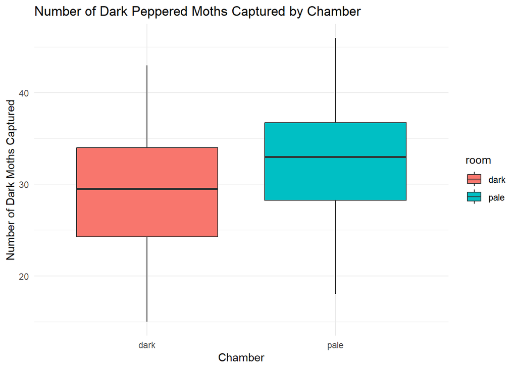

```r
#do not change into ordinal - you will lose the clarity
ggplot(student_data, aes(x = room, y = number, fill = room)) +
  geom_boxplot() +
  labs(title = "Number of Dark Peppered Moths Captured by Chamber",
       x = "Chamber",
       y = "Number of Dark Moths Captured") +
  theme_minimal()
```

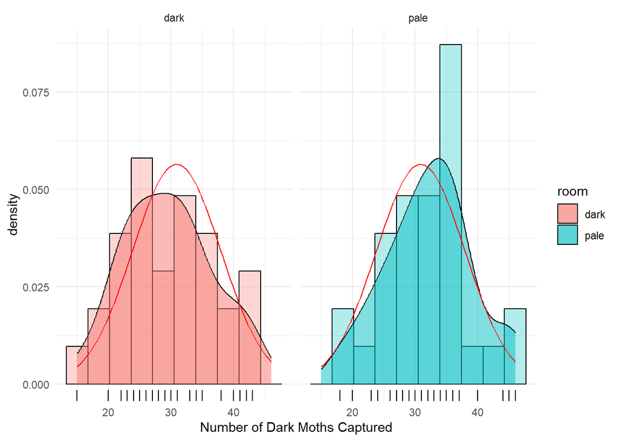

```r
#checking normality
ggplot(student_data, aes(x = number, fill = room)) +
  geom_histogram(aes(y = ..density..), color = "black", alpha = 0.3, bins = 10) +
  geom_density(alpha = 0.5) +
  geom_rug() +
  stat_function(
    fun = dnorm,
    args = list(
      mean = mean(student_data$number),
      sd = sd(student_data$number)
    ),
    color = "red"
  ) +
  facet_grid(. ~ room) + #splits the plot into separate panels for each chamber
  xlab("Number of Dark Moths Captured") +
  theme_minimal()
```

```r
shapiro.test(student_data$number)
```

```
    Shapiro-Wilk normality test

data:  student_data$number
W = 0.98956, p-value = 0.8889
```

As groups are normally distributed and the variances in the two groups don’t differ much, it is safe to use two sample t-test.

```r
#assuming variances are equal
t_result <- t.test(number ~ room, data = student_data, alternative = "two.sided", var.equal = TRUE)
t_result
```

```
    Two Sample t-test

data:  number by room
t = -1.5532, df = 58, p-value = 0.1258
alternative hypothesis: true difference in means between group dark and group pale is not equal to 0
95 percent confidence interval:
 -6.4085412  0.8085412
sample estimates:
mean in group dark mean in group pale
          29.46667           32.26667
```

```r
t_critical <- qt(p = 0.975, df = 58)
t_critical
```

```
[1] 2.001717
```

The t-test showed a non-significant difference between groups (p = 0.126). Although the sample means differ (29.47 vs 32.27), this difference is not statistically significant and could easily occur by chance alone. We want to also be sure and test all bases.

```r
#assuming variances are not equal
t.test(number ~ room, data = student_data, alternative = "two.sided", var.equal = FALSE)
```

```
    Welch Two Sample t-test

data:  number by room
t = -1.5532, df = 57.959, p-value = 0.1258
alternative hypothesis: true difference in means between group dark and group pale is not equal to 0
95 percent confidence interval:
 -6.4085961  0.8085961
sample estimates:
mean in group dark mean in group pale
          29.46667           32.26667
```

```r
wilcox.test(number ~ room, data = student_data, alternative = "two.sided")
```

```
    Wilcoxon rank sum test with continuity correction

data:  number by room
W = 344.5, p-value = 0.1201
alternative hypothesis: true location shift is not equal to 0
```

The Welch Two Sample t-test produced results nearly identical to the standard t-test, with only minor differences in the confidence interval and degrees of freedom. Both t-tests yield a t-statistic of -1.55, which falls below the critical value of approximately 2.00 required for statistical significance at α = 0.05. This indicates that the observed difference in means is not large enough to be considered statistically significant.

The non-parametric Wilcoxon rank sum test aligns with this conclusion, also failing to find sufficient evidence for a difference in distributions between the two groups.

Given that these different approaches all point toward the same conclusion, a final assessment of the model assumptions was conducted to verify the appropriateness of the parametric t-test.

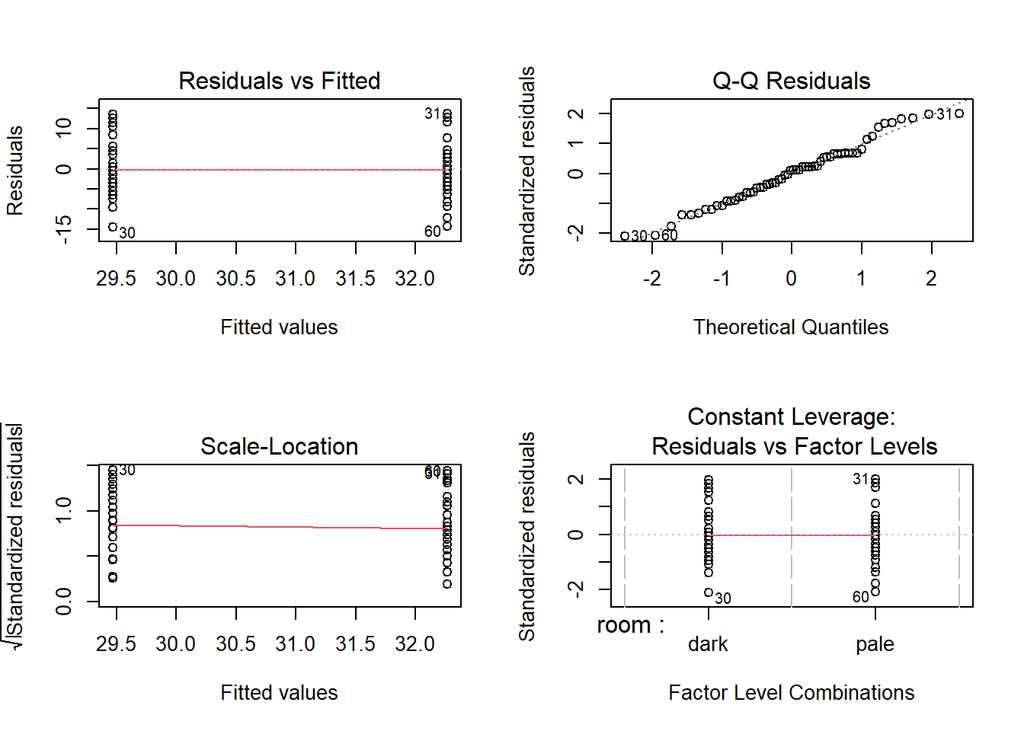

```r
model.1 <- lm(number ~ room, data = student_data)
par(mfrow = c(2,2))
plot(model.1)
```

The first graph shows the spread of the residuals for the two groups and since both columns have roughly the same vertical height (similar range of residuals), the variances are homogeneous. The second graph (QQ plot of the residuals of the model) also seems to depict a straight line, meaning the normality assumption is satisfied. The proof that normality assumption is satisfied can also be verified by the Shapiro Test on residuals below. With W = 0.97992 and p-value = 0.4251 (>0.05), the test indicates that the residuals are normal.

```r
shapiro.test(residuals(model.1))
```

```
    Shapiro-Wilk normality test

data:  residuals(model.1)
W = 0.97992, p-value = 0.4251
```

```r
leveneTest(model.1)
```

```
Levene's Test for Homogeneity of Variance (center = median)
      Df F value Pr(>F)
group  1  0.1386  0.711
      58
```

```r
bptest(model.1)
```

```
    studentized Breusch-Pagan test

data:  model.1
BP = 0.027916, df = 1, p-value = 0.8673
```

### d.

The statistical conclusion (i.e. inference). Do you accept or reject the null hypothesis? (3 points)

Based on the results of the two-sample t-test, we fail to reject the null hypothesis that the mean number of dark peppered moths is the same in dark and pale environments. The decision was made by comparing the calculated t-statistic to the critical t-value from the Student’s t-distribution. The calculated t-statistic from the test is |t_statistic| = 1.5532, and for a two-tailed test with a significance level of = 0.05 and df = 58, the t_critical is 2.002. Since |t_statistic| < t_critical, we fail to reject the null hypothesis.  
The validity of results of t-test were verified by the model’s underlying assumptions. Shapiro-Wilk test was used on the data and the residuals,and QQ Plot indicated no significant deviation from normality. Levene’s Test (F = 0.139 and p = 0.711) and BP Test (BP = 0.028, p = 0.867) confirm the assumption of equal variances. The residual plot also showed the consistent spread for both groups.

Additionally, we have also tried t-test under unequal variances and non-parametric Wilcoxon test. Both of these tests failed to reject null hypothesis, supporting the conclusion from the primary analysis.

### e.

The “biological” conclusion (i.e. a qualified statement about the biological hypothesis concerning moth survival, including an estimate of raw effect size, its precision, and whether an effect of this magnitude seems biologically interesting) (2 points). - **NEEDs REVISION**

The results from this experiment don’t support the biological hypothesis that substrate color affects the survival of dark peppered moths through bird predation. The raw effect size (the observed difference in mean moth counts) was 2.8 moths with the pale room showing a slightly higher mean (32.27) than the dark room (29.47). However, this small observed effect is highly imprecise. The 95% confidence interval for the true difference ranges from -6.41 to +0.81 moths, meaning the data are consistent with a scenario where the dark room could have up to 6.4 fewer moths, both rooms could be equal or dark room could have a slight advantage of 0.8 moths. Given that the confidence interval includes zero and spans both positive and negative values, an effect of this magnitude is not statistically distinguishable from random variation. A difference of 2.8 moths (approximately a 9% change from the mean) is unlikely to represent a biologically meaningful selective pressure, especially considering the lack of precision in the estimate. Therefore, this experiment fails to provide evidence that the camouflage advantage of dark moths on a dark substrate is a strong factor influencing predation rates under these conditions.

### f.

A statement about your confidence in the statistical conclusion (for example with respect to the violation of certain assumptions, to potential biases created by missing data, to suboptimal experimental design, and/or to power issues ) (2 points)

We have high confidence in the statistical conclusion to fail to reject the null hypothesis, as it is robust and supported by multiple lines of evidence. First, all statistical assumptions for the t-test were thoroughly validated; both graphical analysis and formal tests confirmed no significant violations of normality or homoscedasticity. Second, the conclusion was consistently reinforced by alternative approaches, including Welch’s t-test and the non-parametric Wilcoxon test. The main limitation is the issue of low statistical power. A post-hoc power analysis reveals the study had only 33.3% power to detect the observed effect size (d = 0.40) with the given sample size (n=30 per group). This means that if a real effect exists, our experiment had a very low probability of detecting it. Therefore, while we are confident in the statistical conclusion based on the current data, we cannot rule out the possibility of a Type II error (failing to detect a real biological effect).

```r
mean_dark <- t_result$estimate[1]
mean_pale <- t_result$estimate[2]

sd_dark <- sd(student_data$number[student_data$room == "dark"])
sd_pale <- sd(student_data$number[student_data$room == "pale"])

d <- function(u1, u2, sd1, sd2){
  abs(u1 - u2) / sqrt((sd1^2 + sd2^2) / 2)
}

pwr.t.test(n = 30, d = d(u1 = mean_dark, u2 = mean_pale, sd1 = sd_dark, sd2 = sd_pale), sig.level = 0.05, type = "two.sample")
```

```
     Two-sample t test power calculation

              n = 30
              d = 0.4010361
      sig.level = 0.05
          power = 0.3329505
    alternative = two.sided

NOTE: n is number in *each* group
```

```r
bs <- function(formula, data, indices){
  d <- data[indices, ]
  fit <- lm(formula, data = d)
  return(coef(fit))
}

results <- boot(
  data = student_data, statistic = bs, R = 1000,
  formula = number ~ room
)
results
```

```
ORDINARY NONPARAMETRIC BOOTSTRAP


Call:
boot(data = student_data, statistic = bs, R = 1000, formula = number ~
    room)


Bootstrap Statistics :
    original      bias    std. error
t1* 29.46667  0.06289163    1.297117
t2*  2.80000 -0.02009653    1.800547
```

```r
boot.ci(results, type = "bca", index = 2)
```

```
BOOTSTRAP CONFIDENCE INTERVAL CALCULATIONS
Based on 1000 bootstrap replicates

CALL :
boot.ci(boot.out = results, type = "bca", index = 2)

Intervals :
Level       BCa
95%   (-0.722,  6.478 )
Calculations and Intervals on Original Scale
```

## 2. Postdoc data

Analyze the data and determine if the results in `Biston_pd2.csv`support or refute the biological hypothesis.

### a.

a statement of the biological hypothesis and its prediction (1 point)

The mean number of dark peppered moths in pale and dark environment differs because the survival from bird predation depends on the colour of the moth in relation to the colour of the environment. Dark peppered moths are better camouflaged on dark substrates than on pale (non‑polluted) substrates, so a bird will capture fewer dark moths when foraging on a dark substrate than when foraging on a pale substrate.

When the same individual birds are tested in both environments, they will capture significantly fewer dark moths in the dark, polluted environment (where the dark moths are less visible) than in the pale, non-polluted environment.

### b.

a statement of the null hypothesis (1 point)

The null hypothesis is that the mean difference in the number of dark peppered moths captured between the pale and dark chambers is zero.

### c.

fit the adequate statistical model, and evaluate the statistical assumptions *(3 points)*

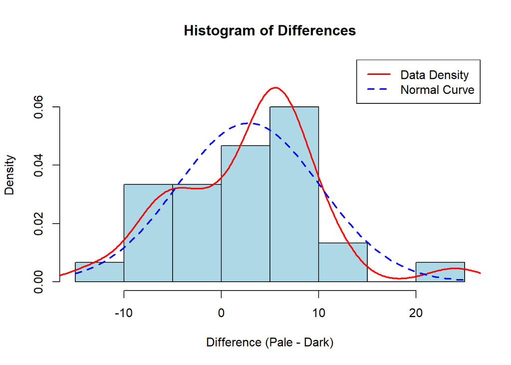

```r
postdoc_data$difference <- postdoc_data$pale - postdoc_data$dark

par(mfrow = c(1, 1))

density_values <- density(postdoc_data$difference)

max_density <- max(density_values$y)

hist(postdoc_data$difference,
     main = "Histogram of Differences",
     xlab = "Difference (Pale - Dark)",
     col = "lightblue",
     probability = TRUE,
     ylim = c(0, max_density * 1.1)) # TRUE helped me to overlay the density curve and normal curve on same scale

lines(density_values, col = "red", lwd = 2)
curve(dnorm(x,
            mean = mean(postdoc_data$difference),
            sd = sd(postdoc_data$difference)),
      col = "blue", lwd = 2, lty = 2, add = TRUE)
legend("topright", legend = c("Data Density", "Normal Curve"),
      col = c("red", "blue"), lty = c(1, 2), lwd = 2)
```

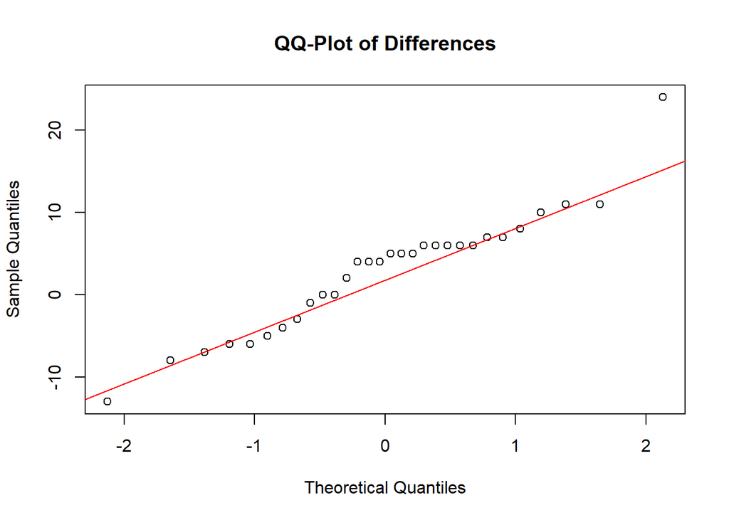

```r
qqnorm(postdoc_data$difference, main = "QQ-Plot of Differences")
qqline(postdoc_data$difference, col = "red")
```

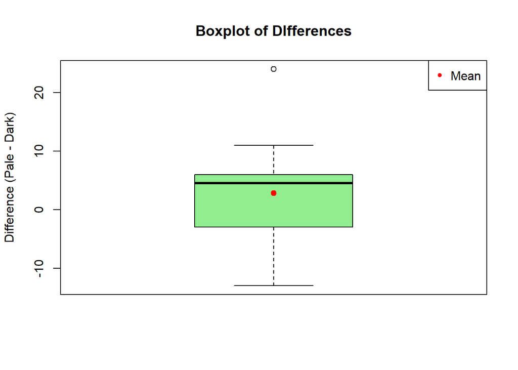

```r
boxplot(postdoc_data$difference,
        main = "Boxplot of DIfferences",
        ylab = "Difference (Pale - Dark)",
        col = "lightgreen")
points(mean(postdoc_data$difference), pch = 20, col = "red", cex = 1.5)
legend("topright", legend = "Mean", pch = 20, col = "red")
```

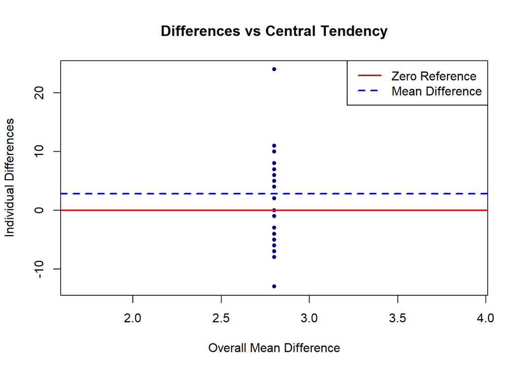

```r
plot(postdoc_data$difference ~ rep(mean(postdoc_data$difference), nrow(postdoc_data)),
    main = "Differences vs Central Tendency",
    xlab = "Overall Mean Difference",
    ylab = "Individual Differences",
    pch = 20, col = "darkblue")

abline(h = 0, col = "red", lwd = 2)
abline(h = mean(postdoc_data$difference), col = "blue", lwd = 2, lty = 2)
legend("topright",
      legend = c("Zero Reference", "Mean Difference"),
      col = c("red", "blue"),
      lty = c(1, 2),
      lwd = 2)
```

```r
shapiro.test(postdoc_data$difference)
```

```
    Shapiro-Wilk normality test

data:  postdoc_data$difference
W = 0.94466, p-value = 0.1215
```

A one-tailed paired t-test was selected as the appropriate statistical model because the experiment had repeated measures, meaning each bird is tested in both chambers. Also, we were testing a directional biological prediction since more dark moths captured in pale chambers.

```r
t.test(postdoc_data$pale, postdoc_data$dark, paired = TRUE, alternative = "greater")
```

```
    Paired t-test

data:  postdoc_data$pale and postdoc_data$dark
t = 2.0932, df = 29, p-value = 0.0226
alternative hypothesis: true mean difference is greater than 0
95 percent confidence interval:
 0.5270879       Inf
sample estimates:
mean difference
            2.8
```

### d.

The statistical conclusion (i.e. inference). Do you accept or reject the null hypothesis? Include your test results. (3 points)

Based on the results of the paired t-test, we reject the null hypothesis that the mean difference in dark moth captures between chambers is zero. The paired t-test yielded a statistically significant result (t_statistic(29) = 2.0932, p-value = 0.0226). Also, the 95% lower confidence bound (0.527 moths) excludes zero, indicating the true effect is positive. In other words, having confidence interval above zero means the effect is consistently positive and zero is not a value for the true effect size. Since |t_statistic| = 2.0932 > |t_critical| = qt(0.95, df = 29) = 1.699, we are safe to reject the null hypothesis.

### e.

The “biological” conclusion (i.e. a qualified statement about the biological hypothesis concerning moth survival, including an estimate of raw effect size, its precision, and whether an effect of this magnitude seems biologically interesting) (2 points).

The results provide clear biological support for the camouflage hypothesis in peppered moths. The raw effect size shows that birds captured an average of 2.8 more dark moths in the pale chamber compared to the dark chamber. However, the precision of this estimate is limited (since the true effect exceeds 0.53 moths), the upper bound is unbounded in this one-tailed framework.

The effect magnitude appears biologically relevant for natural selection. A consistent 2.8-moth advantage per foraging bout, when accumulated across numerous predator-prey interactions, may generate sufficient selective pressure to explain the observed industrial melanism in peppered moth populations.

### f.

A statement about your confidence in the statistical conclusion (for example with respect to the violation of certain assumptions, to potential biases created by missing data, to suboptimal experimental design, and/or to power issues ) (2 points)

We have strong confidence in our conclusion that birds catch more dark moths in pale chambers

## 3. Power issues

Assuming that a difference of 5% (or 2.5 moths) of predation rate between treatments is biologically meaningful, what would be the power to detect this with alpha=0.05 and the data collected by:

### a.

the student? *(1 point)*

```r
d_students <- 2.5 / sqrt((sd_dark^2 + sd_pale^2) / 2)

power_students <- pwr.t.test(
  n = 30,
  d = d_students,
  sig.level = 0.05,
  type = "two.sample",
  alternative = "two.sided"
)

power_students
```

```
     Two-sample t test power calculation

              n = 30
              d = 0.358068
      sig.level = 0.05
          power = 0.2760005
    alternative = two.sided

NOTE: n is number in *each* group
```

For the student’s unpaired design with 30 birds in each group, the power to detect a biologically meaningful difference of 2.5 moths is approximately 27.6%.

### b.

the postdoc? *(1 point)*

**Warning**

`d` for a paired t-test is estimated as $d = \text{mean differences} / \text{sd differences}$

using the `d()` function you can specify it as `d(0, mean differences, sd differences, sd differences)`

```r
d_postdoc <- d(u1 = 2.5, u2 = 0, sd1 = sd(postdoc_data$difference), sd2 = sd(postdoc_data$difference))

power_postdoc <- pwr.t.test(
  n = 30,
  d = d_postdoc,
  sig.level = 0.05,
  type = "paired",
  alternative = "greater"
)

power_postdoc
```

```
     Paired t test power calculation

              n = 30
              d = 0.3412107
      sig.level = 0.05
          power = 0.5714932
    alternative = greater

NOTE: n is number of *pairs*
```

For the postdoc’s paired design with 30 bird pairs, the power to detect the same biologically meaningful difference of 2.5 moths is approximately 57.1%

### c.

Comment the difference between the power using the student and postdoc data. *(1 point)*

The paired postdoc design (57.1% power) provides substantially higher detection capability than the unpaired student design (27.6% power). This >2× increase in power occurs because the paired design reduces variability by controlling for individual bird differences, yielding a more sensitive test.